```python
import numpy as np
import matplotlib.pyplot as plt
```

# Problem 1

**Print Hello World!**

```python
print("Hello World!")
```

```
Hello World!
```

# Problem 2

**User input two numbers a and b. Perform the following algebraic operations c = a+b, d= a-b, e= a*b, f=a/b and g=a%b and print their results**

```python
a = int(input('Enter the value of a : '))
b=int(input('Enter the value of b : '))
c=a+b
print("c =",c)
d=a-b
print("d =",d)
e=a*b
print("e =",e)
f=a/b
print("f =",f)
g=a%b
print("g =",g)
```

```
c = 7
d = -1
e = 12
f = 0.75
g = 3
```

# Problem 3

**Print the factorial of a positive number 'a' given as a user input.**

```python
def factorial(a):
    if (a==0):
        return 1
    else:
        a=a*factorial(a-1)
    return a

a=int(input('Enter a : '))
b=factorial(a)
print("factorial of a is",b)
```

```
factorial of a is 24
```

# Problem 4

**Write a function to print all prime numbers in an interval [a,b]. Interval is to be obtained as a user input.**

```python
def prime(a,b):
    '''
    Returns primes in the interval [a,b] in a list
    '''
    L=[]
    for num in range(a,b+1):
    c=0
    for i in range(1,int(np.sqrt(b))+1):
        if (num % i==0):
            c=c+1
    if (c<=1):
        L.append(num)
    return L

a=int(input("Enter a : "))
b=int(input("Enter b : "))
l1=prime(a,b)
print(l1)
```

```
[11, 13, 17, 19, 23, 29, 31, 37, 41, 43, 47, 53, 59, 61, 67, 71, 73, 79, 83, 89]
```

# Problem 5

**User input two numbers a and b. Print their lowest common multiple(LCM).**

```python
a=int(input('Enter a : '))
b=int(input('Enter b : '))
gcd=1
for i in range(2,min(abs(a),abs(b))+1):
    if (a%i==0) and (b%i==0):
        gcd=i
lcm=int(a*b/gcd)
print("lcm :",lcm)
```

```
Enter a : 4
Enter b : 6
lcm : 12
```

# Problem 6

**Create a list of length n = 15. Sort in descending order and print the sorted list as well as the sorted indices. Use bubble sort algorithm.**

```python
arr=[64, 34, 25, 12, 22, 11, 90,4,35,52,97,57,73,65,61]
n = len(arr)
L=[i for i in range(n)] # List to keep the sorted indices

# Using bubble sort to implement the sorting
for i in range(n-1):
    for j in range(0, n-i-1):
        if arr[j] < arr[j + 1]:
            arr[j], arr[j + 1] = arr[j + 1], arr[j]
            L[j],L[j+1] = L[j+1],L[j]
print(L)
print(arr)
```

```
[10, 6, 12, 13, 0, 14, 11, 9, 8, 1, 2, 4, 3, 5, 7]
[97, 90, 73, 65, 64, 61, 57, 52, 35, 34, 25, 22, 12, 11, 4]
```

# Problem 7

**Repeat the previous program for sorting in ascending order. Use numpy array instead of list.**

```python
arr=np.array([64,34,25,12,22,11,90,4,35,52,97,57,73,65,61])
print('Original Array :', arr)
n = len(arr)
L=np.array(list(range(len(arr))))
for i in range(n-1):
    for j in range(0, n-i-1):
        if arr[j] > arr[j + 1]:
            arr[j], arr[j + 1] = arr[j + 1], arr[j]
            L[j],L[j+1] = L[j+1],L[j]
print("Sorted Array :",arr)
print('Sorted indices :',L)
```

```
Original Array : [64 34 25 12 22 11 90  4 35 52 97 57 73 65 61]
Sorted Array : [ 4 11 12 22 25 34 35 52 57 61 64 65 73 90 97]
Sorted indices : [ 7  5  3  4  2  1  8  9 11 14  0 13 12  6 10]
```

# Problem 8

**Print a matrix $$M \in \mathbb{R}^{mxn}$$ having random values in the given range [ -2, 5 ]. m and n are to be given as a user input.**

```python
m=int(input('Enter value of m : '))
n=int(input('Enter value of n : '))
mat=np.random.randint(-2,5 ,size=(m,n))
print(mat)
```

```
[[ 0 -1 -1 -1]
 [-2  0 -1  0]
 [-2  2  3 -2]
 [-2  4 -1  1]]
```

# Problem 9

**Program to multiply two random matrices $M_{1}$ and $M_{2}$.**

```python
m = int(input("Enter number of rows of matrix 1 : "))
n = int(input("Enter number of columns of matrix 1 : "))
p = int(input("Enter number of columns of matrix 2 : "))

M1=np.random.randint(0,10,size=(m,n))
M2=np.random.randint(0,10,size=(n,p))

print("Matrix 1: ")
print(M1)

print("Matrix 2: ")
print(M2)

def multiply_mat(M,N):
    m,n=M.shape
    q,p=N.shape
    if (n==q):
    A=[]
    for i in range(m):
        L=[]
        for j in range(p):
            term=0
            for k in range(n):
                term+=M[i][k]*N[k][j]
            L.append(term)
        A.append(L)

    return np.array(A)
  else:
    print(f"Number of columns of {M} is not same as number of rows of {N}.")


print("Product Matrix : ")
print(multiply_mat(M1,M2))
```

```
Matrix 1:
[[9 1 6]
 [0 3 4]]
Matrix 2:
[[2 0 0]
 [8 9 7]
 [6 9 8]]
Product Matrix :
[[62 63 55]
 [48 63 53]]
```

Mulitplication using in-built function :

```python
np.dot(M1,M2)
```

```
array([[62, 63, 55],
       [48, 63, 53]])
```

# Problem 10

**Generate 100 points in $\mathbb{R}^{10}$**

```python
n=100
x=np.random.rand(10,1)
X=x
for i in range(n-1):
    x=np.random.rand(10,1)
    X=np.append(X,x,axis=1)
print(X.shape)
```

```
(10, 100)
```

Saving points in a CSV file

```python
np.savetxt("points.csv", X, delimiter=",")
```

# Problem 11

**Read the csv file generated in the previous program to a matrix. Each column of the matrix should represent a vector**

**Compute the following:**

C = $\frac{1}{n}$ $\Sigma_{i=0}^{n}$$(x_{i}−\mu)(x_{i}−\mu)^{T}$

where $x_{i}= [x_{i1}, ...x_{i10}]^{T}$, i=1,...n, is a column and μ is mean of all columns.

```python
points=np.loadtxt(open("points.csv", "r"), delimiter=",")
```

```python
mu=points.mean(axis=1)
print(mu)
```

```
[0.52604235 0.50922085 0.48802571 0.4724369  0.5009211  0.47608926
 0.48496315 0.49727325 0.48107702 0.48236383]
```

```python
C=np.dot(np.transpose(np.transpose(points)-mu),np.transpose(points)-mu)
C=C/n
print(C)
```

```
[[ 0.07977206 -0.00670791  0.00066195  0.00053548  0.01077338 -0.00052025
  -0.00585247  0.01096335 -0.02096359  0.00057175]
 [-0.00670791  0.0728318  -0.00330354 -0.01064782  0.00723052 -0.00309482
   0.00768548 -0.00343543  0.02308002 -0.00034636]
 [ 0.00066195 -0.00330354  0.0933543  -0.00419422  0.0062237  -0.01206494
  -0.00204774 -0.00403214 -0.02363039  0.02074276]
 [ 0.00053548 -0.01064782 -0.00419422  0.08902594 -0.00380106  0.00782169
  -0.00662676 -0.00354553 -0.02011961  0.00233338]
 [ 0.01077338  0.00723052  0.0062237  -0.00380106  0.09212979 -0.00185117
   0.00317663 -0.00886644 -0.00453258  0.0054605 ]
 [-0.00052025 -0.00309482 -0.01206494  0.00782169 -0.00185117  0.08539993
   0.00195707 -0.00015459  0.00937051 -0.00866557]
 [-0.00585247  0.00768548 -0.00204774 -0.00662676  0.00317663  0.00195707
   0.08000707  0.01028011  0.00389919  0.00354116]
 [ 0.01096335 -0.00343543 -0.00403214 -0.00354553 -0.00886644 -0.00015459
   0.01028011  0.07573684 -0.01690316  0.00840226]
 [-0.02096359  0.02308002 -0.02363039 -0.02011961 -0.00453258  0.00937051
   0.00389919 -0.01690316  0.10140322 -0.01098209]
 [ 0.00057175 -0.00034636  0.02074276  0.00233338  0.0054605  -0.00866557
   0.00354116  0.00840226 -0.01098209  0.08402066]]
```

# Problem 12

**Define a class for a complex number $a+jb$. Define memeber functions to do basic operations conjugate, absolute value, addition, subtraction, multiplication, division and angle. Define two complex numbers $c1,c2$ and print the results of the following operations $c1+c2, c1−c2, c1∗c2, c1/c2, |c1|, |c2|, ∠c1, ∠c2.$**

```python
from math import sqrt
from math import atan
```

```python
class complex():
    def __init__(self,real_part,imaginary_part):
    self.real=real_part
    self.imaginary=imaginary_part

    def __str__(self):
        if self.imaginary < 0:
            return f'{self.real}{self.imaginary}i'
        if self.imaginary > 0:
            return f'{self.real}+{self.imaginary}i'
        if self.imaginary==0:
            return f'{self.real}'

    def conjugate(self):
    '''
    returns complex conjugate
    '''
    return complex(self.real,-self.imaginary)

    def absolute_value(self):
    '''
    returns absolute value
    '''
    return np.sqrt((self.real)**2+(self.imaginary)**2)

    def addition(self,number):
    '''
    perfor addition
    '''
    return complex(self.real+number.real,self.imaginary+number.imaginary)

    def substraction(self,number):
    '''
    perform substraction
    '''
    return complex(self.real-number.real,self.imaginary-number.imaginary)

    def multiply(self,number):
    '''
    perform multiplication
    '''
    return complex(self.real*number.real-self.imaginary*number.imaginary,self.real*number.imaginary+self.imaginary*number.real)

    def divide(self,number):
    '''
    perform divsion
    '''
    result_real=(self.real*number.real+self.imaginary*number.imaginary)/((number.real)**2+(number.imaginary)**2)
    result_imag=(self.imaginary*number.real-self.real*number.imaginary)/((number.real)**2+(number.imaginary)**2)
    result=complex(result_real,result_imag)
    return result

    def angle(self):
    '''
    returns angle between -pi/2 and pi/2
    '''
    return np.arctan(self.imaginary/self.real)
```

```python
c1=complex(1,2)
c2=complex(3,4)

# c1 + c2

print(f'({c1})+({c2}) =',c1.addition(c2))

# c1-c2
c4=c1.substraction(complex(4,5))
print(f'({c1})-({c2}) =',c1.substraction(c2))

# c1*c2
mult=c1.multiply(c2)
print(f'({c1})*({c2}) =',mult)

# c1/c2
print(f'({c1})/({c2}) =',c1.divide(c2))

# |c1|
print(f'Absolute value of {c1} :',c1.absolute_value())
# |c2|
print(f'Absolute value of {c2} :',c2.absolute_value())

# angle of c1
print(f'Angle of {c1} :',c1.angle())
# angle of c2
print(f'Angle of {c2} :',c2.angle())
```

```
(1+2i)+(3+4i) = 4+6i
(1+2i)-(3+4i) = -2-2i
(1+2i)*(3+4i) = -5+10i
(1+2i)/(3+4i) = 0.44+0.08i
Absolute value of 1+2i : 2.23606797749979
Absolute value of 3+4i : 5.0
Angle of 1+2i : 1.1071487177940904
Angle of 3+4i : 0.9272952180016122
```

# Problem 13

**Plot the function $y=3x+2$ with $x \in [−10,10]$**

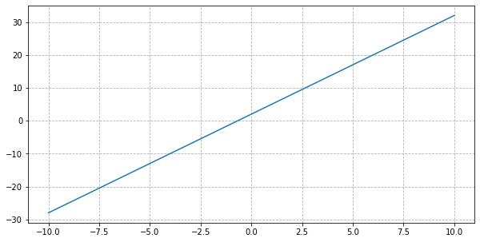

```python
x=np.linspace(-10,10,100) # 100 random points in the interval [-10,10]
y=3*x+2
plt.figure(figsize=(10,5))
plt.plot(x,y)
plt.grid(linestyle='--')
plt.show()
```

# Problem 14

**Scatter plot $100$ points within an ellipse with center $(5,-5)$ and has major axis $2a=10$ and minor axis $2b=5$.**

```python
a=5
b=2.5
mu_x=5
mu_y=-5
```

Random points inside the ellipse

Equation of an ellipse with center $(\mu_{x},\mu_{y})$ with major axis $2a=10$ and minor axis $2b=5$ can be parameterized by the equations

$x=\mu_{x}+a*cos(t), y=\mu_{y}+b*sin(t)$, $t \in [0,2\pi]$

To generate a point inside this ellipse, take random points $a_{1}$,$b_{1}$,$t$ in the interval $[0,a]$, $[0,b]$, $[0,2\pi]$ respectively, then the point

$(x,y)$ where $x=\mu_{x}+a_{1}*cos(t)$, $y=\mu_{y}+b_{1}*sin(t)$

is a point inside the ellipse.

**Note**: The equations

$x=\mu_{x}+a_{1}*cos(t)$, $y=\mu_{y}+b_{1}*sin(t)$, $t \in [0,2\pi]$

represents an ellipse which lies inside the ellipse

$x=\mu_{x}+a*cos(t), y=\mu_{y}+b*sin(t)$, $t \in [0,2\pi]$

if $a_{1}<a$, ${b_1} < b$. Fixing a value of $t \in [0,2\pi]$, will give a random point inside the ellipse.

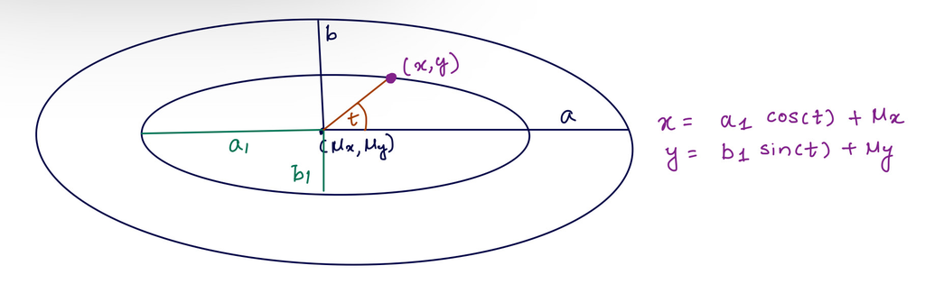

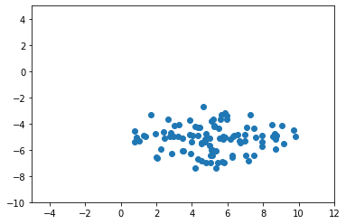

```python
a1=np.random.rand(100)*5
b1=np.random.rand(100)*2.5
t=np.random.rand(100)*(2*np.pi)
plt.xlim([-5,12])
plt.ylim([-10,5])
plt.scatter(a1*np.cos(t)+mu_x,b1*np.sin(t)+mu_y)
```